# INN Hotels Project

#### Bi-Variate Analysis

```python
inn.columns
```

```
Index(['Booking_ID', 'no_of_adults', 'no_of_children', 'no_of_weekend_nights',
       'no_of_week_nights', 'type_of_meal_plan', 'required_car_parking_space',
       'room_type_reserved', 'lead_time', 'arrival_year', 'arrival_month',
       'arrival_date', 'market_segment_type', 'repeated_guest',
       'no_of_previous_cancellations', 'no_of_previous_bookings_not_canceled',
       'avg_price_per_room', 'no_of_special_requests', 'booking_status'],
      dtype='object')
```

```
booking_status  Canceled  Not_Canceled    All
repeated_guest
All                11885         24390  36275
0                  11869         23476  35345
1                     16           914    930
------------------------------------------------------------------------------------------------------------------------
```

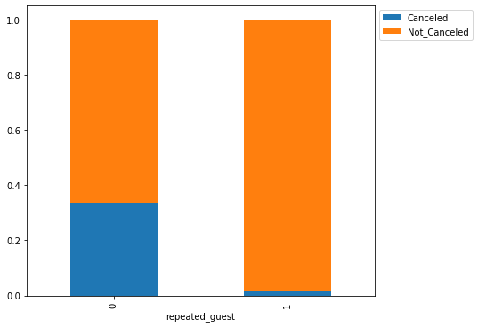

```python
stacked_barplot(inn, cols_to_chart[12], 'booking_status')
```

```python
round((16/ 930),2) # percentage of repeat guests that cancel
```

```
0.02
```

```python
# A repeat guest is far less likely to cancel compared to a first time guest.
```

```
booking_status          Canceled  Not_Canceled    All
no_of_special_requests
All                        11885         24390  36275
0                           8545         11232  19777
1                           2703          8670  11373
2                            637          3727   4364
3                              0           675    675
4                              0            78     78
5                              0             8      8
------------------------------------------------------------------------------------------------------------------------
```

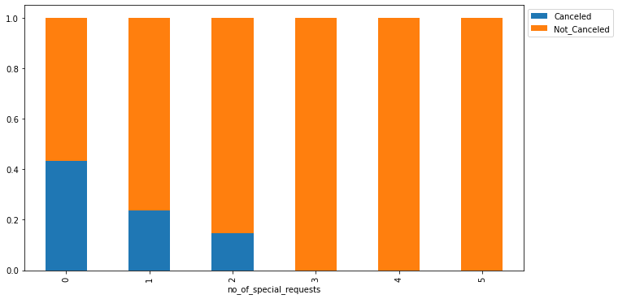

```python
stacked_barplot(inn, cols_to_chart[16], 'booking_status')
```

```python
# Bookings without a special request may be more likely to cancel compared to 1 or more special requests.
```

```
booking_status  Canceled  Not_Canceled    All
arrival_year
All                11885         24390  36275
2018               10924         18837  29761
2017                 961          5553   6514
------------------------------------------------------------------------------------------------------------------------
```

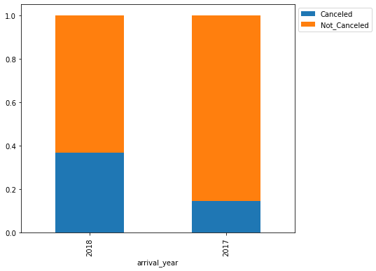

```python
stacked_barplot(inn, cols_to_chart[8], 'booking_status')
```

```python
# When considered proporitonally, 2018 has had far more cancellations than 2017, indicating a trend
```

```python
# Check for statistical significance using chi-square test
```

```python
crosstab = pd.crosstab(
    inn["repeated_guest"], inn["no_of_previous_cancellations"]
)  # Contingency table of repeat guest and booking status attributes

Ho = "Repeat guest has no effect on previous cancellations"  # Stating the Null Hypothesis
Ha = "Repeat guest has an effect on previous cancellations"  # Stating the Alternate Hypothesis

chi, p_value, dof, expected = stats.chi2_contingency(crosstab)

if p_value < 0.05:  # Setting our significance level at 5%
    print(f"{Ha} as the p_value ({p_value}) < 0.05")
else:
    print(f"{Ho} as the p_value ({p_value})) > 0.05")
```

```
Repeat guest has an effect on previous cancellations as the p_value (0.0) < 0.05
```

```python
crosstab = pd.crosstab(
    inn["repeated_guest"], inn["no_of_previous_cancellations"]
)  # Contingency table of repeat guest and booking status attributes

Ho = "Repeat guest has no effect on previous cancellations"  # Stating the Null Hypothesis
Ha = "Repeat guest has an effect on previous cancellations"  # Stating the Alternate Hypothesis

chi, p_value, dof, expected = stats.chi2_contingency(crosstab)

if p_value < 0.05:  # Setting our significance level at 5%
    print(f"{Ha} as the p_value ({p_value}) < 0.05")
else:
    print(f"{Ho} as the p_value ({p_value})) > 0.05")
```

```
Repeat guest has an effect on previous cancellations as the p_value (0.0) < 0.05
```

```python
crosstab = pd.crosstab(
    inn["no_of_special_requests"], inn["no_of_previous_cancellations"]
)  # Contingency table of repeat guest and booking status attributes

Ho = "Special Requests have no effect on previous cancellations"  # Stating the Null Hypothesis
Ha = "Special Requests have an effect on previous cancellations"  # Stating the Alternate Hypothesis

chi, p_value, dof, expected = stats.chi2_contingency(crosstab)

if p_value < 0.05:  # Setting our significance level at 5%
    print(f"{Ha} as the p_value ({p_value}) < 0.05")
else:
    print(f"{Ho} as the p_value ({p_value})) > 0.05")
```

```
Special Requests have an effect on previous cancellations as the p_value (4.215734617582017e-13) < 0.05
```

```python
crosstab = pd.crosstab(
    inn["arrival_year"], inn["no_of_previous_cancellations"]
)  # Contingency table of repeat guest and booking status attributes

Ho = "Arrival year has no effect on previous cancellations"  # Stating the Null Hypothesis
Ha = "Arrival year has an effect on previous cancellations"  # Stating the Alternate Hypothesis

chi, p_value, dof, expected = stats.chi2_contingency(crosstab)

if p_value < 0.05:  # Setting our significance level at 5%
    print(f"{Ha} as the p_value ({p_value}) < 0.05")
else:
    print(f"{Ho} as the p_value ({p_value})) > 0.05")
```

```
Arrival year has an effect on previous cancellations as the p_value (8.55952510596434e-38) < 0.05
```

```python
# I've identified that Repeat guest status, Amount of special requests, and Arrival Year all have an effect on number of previous cancellations
```

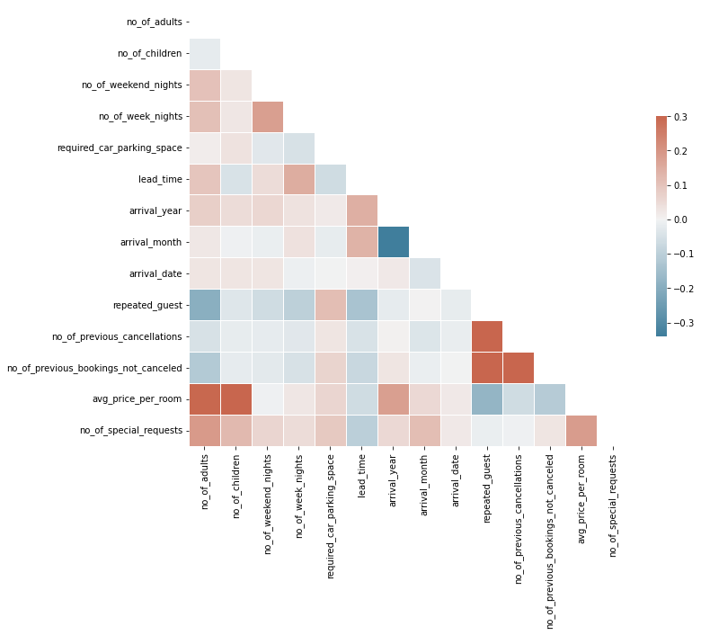

```python
# Compute the correlation matrix
corr = inn.corr()

# Generate a mask for the upper triangle
mask = np.triu(np.ones_like(corr, dtype=bool))

# Set up the matplotlib figure
f, ax = plt.subplots(figsize=(11, 9))

# Generate a custom diverging colormap
cmap = sns.diverging_palette(230, 20, as_cmap=True)

# Draw the heatmap with the mask and correct aspect ratio
sns.heatmap(corr, mask=mask, cmap=cmap, vmax=.3, center=0,
            square=True, linewidths=.5, cbar_kws={"shrink": .5});
```

## Checking Multicollinearity

- In order to make statistical inferences from a logistic regression model, it is important to ensure that there is no multicollinearity present in the data.

```python
inn.info()
```

```
<class 'pandas.core.frame.DataFrame'>
RangeIndex: 36275 entries, 0 to 36274
Data columns (total 19 columns):
 #   Column                                Non-Null Count  Dtype
---  ------                                --------------  -----
 0   Booking_ID                            36275 non-null  object
 1   no_of_adults                          36275 non-null  int64
 2   no_of_children                        36275 non-null  int64
 3   no_of_weekend_nights                  36275 non-null  int64
 4   no_of_week_nights                     36275 non-null  int64
 5   type_of_meal_plan                     36275 non-null  object
 6   required_car_parking_space            36275 non-null  int64
 7   room_type_reserved                    36275 non-null  object
 8   lead_time                             36275 non-null  int64
 9   arrival_year                          36275 non-null  int64
 10  arrival_month                         36275 non-null  int64
 11  arrival_date                          36275 non-null  int64
 12  market_segment_type                   36275 non-null  object
 13  repeated_guest                        36275 non-null  int64
 14  no_of_previous_cancellations          36275 non-null  int64
 15  no_of_previous_bookings_not_canceled  36275 non-null  int64
 16  avg_price_per_room                    36275 non-null  float64
 17  no_of_special_requests                36275 non-null  int64
 18  booking_status                        36275 non-null  object
dtypes: float64(1), int64(13), object(5)
memory usage: 5.3+ MB
```

```python
inn = inn.drop("Booking_ID", axis=1) #Drop BookingID categorical to avoid overload of dummy variables
```

```python
inn['booking_status'].replace('Not_Canceled', 1, inplace=True)
inn['booking_status'].replace('Canceled', 0, inplace=True)
```

```python
X = inn.drop("booking_status", axis=1)
Y = inn["booking_status"]

# creating dummy variables
X = pd.get_dummies(X, drop_first=True)


# adding constant
X = sm.add_constant(X)

# splitting in training and test set
X_train, X_test, y_train, y_test = train_test_split(X, Y, test_size=0.3, random_state=1)
```

```python
X_train.shape
```

```
(25392, 28)
```

```python
vif_series = pd.Series(
    [variance_inflation_factor(X_train.values, i) for i in range(X_train.shape[1])],
    index=X_train.columns,
    dtype=float,
)
print("Series before feature selection: \n\n{}\n".format(vif_series))
```

```
Series before feature selection:

const                                   3.946816e+07
no_of_adults                            1.348154e+00
no_of_children                          1.978229e+00
no_of_weekend_nights                    1.069475e+00
no_of_week_nights                       1.095667e+00
required_car_parking_space              1.039928e+00
lead_time                               1.394914e+00
arrival_year                            1.430830e+00
arrival_month                           1.275673e+00
arrival_date                            1.006738e+00
repeated_guest                          1.783516e+00
no_of_previous_cancellations            1.395689e+00
no_of_previous_bookings_not_canceled    1.651986e+00
avg_price_per_room                      2.050421e+00
no_of_special_requests                  1.247278e+00
type_of_meal_plan_Meal Plan 2           1.271851e+00
type_of_meal_plan_Meal Plan 3           1.025216e+00
type_of_meal_plan_Not Selected          1.272183e+00
room_type_reserved_Room_Type 2          1.101438e+00
room_type_reserved_Room_Type 3          1.003302e+00
room_type_reserved_Room_Type 4          1.361515e+00
room_type_reserved_Room_Type 5          1.027810e+00
room_type_reserved_Room_Type 6          1.973072e+00
room_type_reserved_Room_Type 7          1.115123e+00
market_segment_type_Complementary       4.500109e+00
market_segment_type_Corporate           1.692844e+01
market_segment_type_Offline             6.411392e+01
market_segment_type_Online              7.117643e+01
dtype: float64
```

```python
# Because we see no VIF above 5 (except for dummy variables) the requirement for multicollinearity is satisfied
```

## Building a Logistic Regression model

```python
# fitting logistic regression model
logit = sm.Logit(y_train, X_train.astype(float))
lg = logit.fit(disp=False)

print(lg.summary())
```

```
                           Logit Regression Results
==============================================================================
Dep. Variable:         booking_status   No. Observations:                25392
Model:                          Logit   Df Residuals:                    25364
Method:                           MLE   Df Model:                           27
Date:                Fri, 29 Jul 2022   Pseudo R-squ.:                  0.3293
Time:                        12:55:54   Log-Likelihood:                -10793.
converged:                      False   LL-Null:                       -16091.
Covariance Type:            nonrobust   LLR p-value:                     0.000
========================================================================================================
                                           coef    std err          z      P>|z|      [0.025      0.975]
--------------------------------------------------------------------------------------------------------
const                                  924.5923    120.817      7.653      0.000     687.795    1161.390
no_of_adults                            -0.1135      0.038     -3.017      0.003      -0.187      -0.040
no_of_children                          -0.1563      0.057     -2.732      0.006      -0.268      -0.044
no_of_weekend_nights                    -0.1068      0.020     -5.398      0.000      -0.146      -0.068
no_of_week_nights                       -0.0398      0.012     -3.239      0.001      -0.064      -0.016
required_car_parking_space               1.5939      0.138     11.561      0.000       1.324       1.864
lead_time                               -0.0157      0.000    -58.868      0.000      -0.016      -0.015
arrival_year                            -0.4570      0.060     -7.633      0.000      -0.574      -0.340
arrival_month                            0.0415      0.006      6.418      0.000       0.029       0.054
arrival_date                            -0.0005      0.002     -0.252      0.801      -0.004       0.003
repeated_guest                           2.3469      0.617      3.805      0.000       1.138       3.556
no_of_previous_cancellations            -0.2664      0.086     -3.108      0.002      -0.434      -0.098
no_of_previous_bookings_not_canceled     0.1727      0.153      1.131      0.258      -0.127       0.472
avg_price_per_room                      -0.0188      0.001    -25.404      0.000      -0.020      -0.017
no_of_special_requests                   1.4690      0.030     48.790      0.000       1.410       1.528
type_of_meal_plan_Meal Plan 2           -0.1768      0.067     -2.654      0.008      -0.307      -0.046
type_of_meal_plan_Meal Plan 3          -17.8379   5057.776     -0.004      0.997   -9930.897    9895.222
type_of_meal_plan_Not Selected          -0.2782      0.053     -5.245      0.000      -0.382      -0.174
room_type_reserved_Room_Type 2           0.3610      0.131      2.761      0.006       0.105       0.617
room_type_reserved_Room_Type 3           0.0009      1.310      0.001      0.999      -2.567       2.569
room_type_reserved_Room_Type 4           0.2821      0.053      5.305      0.000       0.178       0.386
room_type_reserved_Room_Type 5           0.7176      0.209      3.432      0.001       0.308       1.127
room_type_reserved_Room_Type 6           0.9456      0.147      6.434      0.000       0.658       1.234
room_type_reserved_Room_Type 7           1.3964      0.293      4.767      0.000       0.822       1.971
market_segment_type_Complementary       41.8798   8.42e+05   4.98e-05      1.000   -1.65e+06    1.65e+06
market_segment_type_Corporate            1.1935      0.266      4.487      0.000       0.672       1.715
market_segment_type_Offline              2.1955      0.255      8.625      0.000       1.697       2.694
market_segment_type_Online               0.3990      0.251      1.588      0.112      -0.093       0.891
========================================================================================================
```

## Model performance evaluation

##### Negative Coefficients indicate a higher correlation with cancellations. Little investement required by the customer means complementary rooms are not often cancelled. Likewise, repeat guests are less likely to cancel

##### While 'Meal Plan 3' has a large negative value, the P-value indicates this isn't a significant variable.

##### Ideally, we want to reduce False Positives and False negatives. We want to accurately identify sitatuations that lead customers to cancel as well as situations that lead to bookins being kept. In that way, we could develop compaines policies that encourage keeping bookings while discouraging cancellations. We will want to maximixe the F1 score to get the best of both metrics

```python
# defining a function to compute different metrics to check performance of a classification model built using statsmodels
def model_performance_classification_statsmodels(
    model, predictors, target, threshold=0.5
):
    """
    Function to compute different metrics to check classification model performance

    model: classifier
    predictors: independent variables
    target: dependent variable
    threshold: threshold for classifying the observation as class 1
    """

    # checking which probabilities are greater than threshold
    pred_temp = model.predict(predictors) > threshold
    # rounding off the above values to get classes
    pred = np.round(pred_temp)

    acc = accuracy_score(target, pred)  # to compute Accuracy
    recall = recall_score(target, pred)  # to compute Recall
    precision = precision_score(target, pred)  # to compute Precision
    f1 = f1_score(target, pred)  # to compute F1-score

    # creating a dataframe of metrics
    df_perf = pd.DataFrame(
        {"Accuracy": acc, "Recall": recall, "Precision": precision, "F1": f1,},
        index=[0],
    )

    return df_perf
```

```python
# defining a function to plot the confusion_matrix of a classification model


def confusion_matrix_statsmodels(model, predictors, target, threshold=0.5):
    """
    To plot the confusion_matrix with percentages

    model: classifier
    predictors: independent variables
    target: dependent variable
    threshold: threshold for classifying the observation as class 1
    """
    y_pred = model.predict(predictors) > threshold
    cm = confusion_matrix(target, y_pred)
    labels = np.asarray(
        [
            ["{0:0.0f}".format(item) + "\n{0:.2%}".format(item / cm.flatten().sum())]
            for item in cm.flatten()
        ]
    ).reshape(2, 2)

    plt.figure(figsize=(6, 4))
    sns.heatmap(cm, annot=labels, fmt="")
    plt.ylabel("True label")
    plt.xlabel("Predicted label")
```

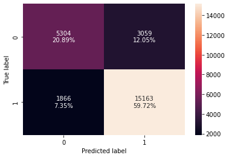

```python
confusion_matrix_statsmodels(lg, X_train, y_train)
```

```python
print("Training performance:")
model_performance_classification_statsmodels(lg, X_train, y_train)
```

```
Training performance:
```

|  | Accuracy | Recall | Precision | F1 |
| --- | --- | --- | --- | --- |
| 0 | 0.806041 | 0.890422 | 0.832126 | 0.860288 |

```python
log_reg_model_test_perf = model_performance_classification_statsmodels(
    lg, X_test, y_test
)

print("Test performance:")
log_reg_model_test_perf
```

```
Test performance:
```

|  | Accuracy | Recall | Precision | F1 |
| --- | --- | --- | --- | --- |
| 0 | 0.804925 | 0.887379 | 0.834654 | 0.860209 |

```python
# Train and test stats are nearly identical indicating that overfitting isn't a concern.
```

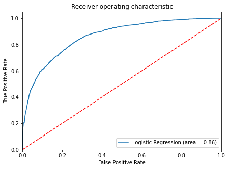

```python
logit_roc_auc_train = roc_auc_score(y_train, lg.predict(X_train))
fpr, tpr, thresholds = roc_curve(y_train, lg.predict(X_train))
plt.figure(figsize=(7, 5))
plt.plot(fpr, tpr, label="Logistic Regression (area = %0.2f)" % logit_roc_auc_train)
plt.plot([0, 1], [0, 1], "r--")
plt.xlim([0.0, 1.0])
plt.ylim([0.0, 1.05])
plt.xlabel("False Positive Rate")
plt.ylabel("True Positive Rate")
plt.title("Receiver operating characteristic")
plt.legend(loc="lower right")
plt.show()
```

```python
# Good performance on Training data
```

```python
# Optimal threshold as per AUC-ROC curve
# The optimal cut off would be where tpr is high and fpr is low
fpr, tpr, thresholds = roc_curve(y_train, lg.predict(X_train))

optimal_idx = np.argmax(tpr - fpr)
optimal_threshold_auc_roc = thresholds[optimal_idx]
print(optimal_threshold_auc_roc, 'Is the optimal classification threshold')
```

```
0.6354994383920195 Is the optimal classification threshold
```

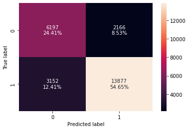

```python
# creating confusion matrix
confusion_matrix_statsmodels(
    lg, X_train, y_train, threshold=optimal_threshold_auc_roc
)
```

```python
# checking model performance for this model
log_reg_model_train_perf_threshold_auc_roc = model_performance_classification_statsmodels(
    lg, X_train, y_train, threshold=optimal_threshold_auc_roc
)
print("Training performance:")
log_reg_model_train_perf_threshold_auc_roc
```

```
Training performance:
```

|  | Accuracy | Recall | Precision | F1 |
| --- | --- | --- | --- | --- |
| 0 | 0.790564 | 0.814904 | 0.864988 | 0.839199 |

```python
# precision is the only metric that increased. Other metrics held or reduced
```

**Checking model performance on test set**

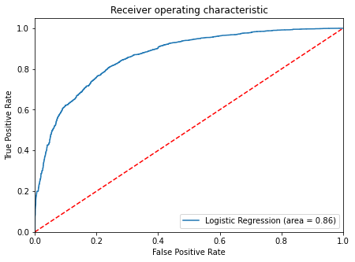

```python
logit_roc_auc_train = roc_auc_score(y_test, lg.predict(X_test))
fpr, tpr, thresholds = roc_curve(y_test, lg.predict(X_test))
plt.figure(figsize=(7, 5))
plt.plot(fpr, tpr, label="Logistic Regression (area = %0.2f)" % logit_roc_auc_train)
plt.plot([0, 1], [0, 1], "r--")
plt.xlim([0.0, 1.0])
plt.ylim([0.0, 1.05])
plt.xlabel("False Positive Rate")
plt.ylabel("True Positive Rate")
plt.title("Receiver operating characteristic")
plt.legend(loc="lower right")
plt.show()
```

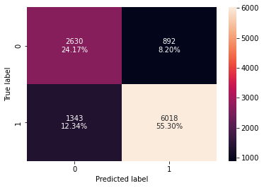

```python
# creating confusion matrix
confusion_matrix_statsmodels(lg, X_test, y_test, threshold=optimal_threshold_auc_roc)
```

```python
# checking model performance for this model
log_reg_model_test_perf_threshold_auc_roc = model_performance_classification_statsmodels(
    lg, X_test, y_test, threshold=optimal_threshold_auc_roc
)
print("Test performance:")
log_reg_model_test_perf_threshold_auc_roc
```

```
Test performance:
```

|  | Accuracy | Recall | Precision | F1 |
| --- | --- | --- | --- | --- |
| 0 | 0.794634 | 0.817552 | 0.870912 | 0.843389 |

```python
# Precision and F1 both increased slightly from training to test, a good indicator.
```

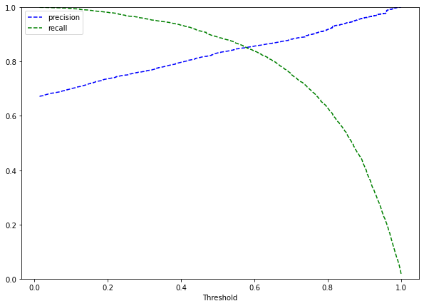

```python
y_scores = lg.predict(X_train)
prec, rec, tre = precision_recall_curve(y_train, y_scores,)


def plot_prec_recall_vs_tresh(precisions, recalls, thresholds):
    plt.plot(thresholds, precisions[:-1], "b--", label="precision")
    plt.plot(thresholds, recalls[:-1], "g--", label="recall")
    plt.xlabel("Threshold")
    plt.legend(loc="upper left")
    plt.ylim([0, 1])


plt.figure(figsize=(10, 7))
plot_prec_recall_vs_tresh(prec, rec, tre)
plt.show()
```

```python
#A threshold of 0.58 balances recall and precision
```

```python
# setting the threshold
optimal_threshold_curve = 0.58
```

**Checking model performance on training set**

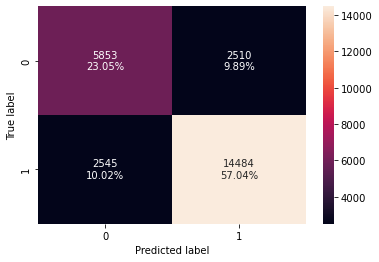

```python
# creating confusion matrix
confusion_matrix_statsmodels(lg, X_train, y_train, threshold=optimal_threshold_curve)
```

```python
log_reg_model_train_perf_threshold_curve = model_performance_classification_statsmodels(
    lg, X_train, y_train, threshold=optimal_threshold_curve
)
print("Training performance:")
log_reg_model_train_perf_threshold_curve
```

```
Training performance:
```

|  | Accuracy | Recall | Precision | F1 |
| --- | --- | --- | --- | --- |
| 0 | 0.800922 | 0.850549 | 0.852301 | 0.851424 |

```python
# While the model is maintaining solid metrics, there wasn't marked improvement from an optimizaed threshold
```

**Checking model performance on test set**

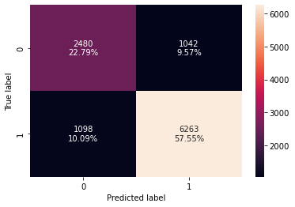

```python
# creating confusion matrix
confusion_matrix_statsmodels(lg, X_test, y_test, threshold=optimal_threshold_curve)
```

```python
log_reg_model_test_perf_threshold_curve = model_performance_classification_statsmodels(
    lg, X_test, y_test, threshold=optimal_threshold_curve
)
print("Test performance:")
log_reg_model_test_perf_threshold_curve
```

```
Test performance:
```

|  | Accuracy | Recall | Precision | F1 |
| --- | --- | --- | --- | --- |
| 0 | 0.803363 | 0.850835 | 0.857358 | 0.854084 |